# [MATRiX data challenge] Serene

### Please take data of any 2 stock tickers (1=C for financial services; other can be of your choice) from the web for the most recent 1 year.

1) Use different Time Series approaches to forecast closing price for next 10 days period in recent past and validate the estimates with actual. You can code in R/python.

2) Supplement your approach with visualizations, statistical reasons in comments.

### Summary

In this project, I collected stock information on **Citigroup** and **Netflix** on Yahoo Finance. Three models including **ARIMA**, **prophet**, and **LSTM** are tested. The latter two models implemented to both stocks. The ARMA model was denied for Netflix data as the stock closing price is lack of stationarity, which is an important assumption studying time series data.

I measured the model performance with **MSE** and **running time** and is concluded below.

```
|                   |  ARIMA | Prophet |   LSTM   |
| ----------------- | ------ |-------- |----------|
| MSE on C          |  0.64  | 5.08    |  19.66   |
| MSE on NFLX       |    /   | 3562.93 | 1436.34  |
| Running time on C | 17.477 | 2.318   |  53.106  |
```

I would say LSTM has a better performance on complex data, especially for dealing with fluctuate series data like the closing price for Netflix, the MSE is significantly smaller than that of Prophet. However, Prophet has a much smaller running time. ARIMA has the smallest MSE among the three models, but the assumptions of the model is really strict. Also, it may take longer hours when tuning parameters.

```python
from pandas_datareader import data, wb
import pandas as pd
import numpy as np
import datetime
import time
```

```python
import matplotlib.pyplot as plt
import seaborn as sns
sns.set_style('whitegrid')
%matplotlib inline
```

### collecting data

Citigroup and Netflix are selected. Stocks price collected from the past year, and the predication period would be Jan 16th to Jan 26th, 2021.

```python
start = datetime.datetime(2020, 1, 16)
end = datetime.datetime(2021, 1, 26)
```

```python
# collect stock info
# Citigroup
C = data.DataReader("C", 'yahoo', start, end)
# AMC entertainment holdings
NFLX = data.DataReader("NFLX", 'yahoo', start, end)
```

```python
C.head()
```

| Date | High | Low | Open | Close | Volume | Adj Close |
| --- | --- | --- | --- | --- | --- | --- |
| 2020-01-16 | 82.129997 | 80.849998 | 81.959999 | 81.000000 | 10426000.0 | 77.858185 |
| 2020-01-17 | 81.400002 | 80.809998 | 81.160004 | 81.120003 | 12413100.0 | 77.973541 |
| 2020-01-21 | 80.910004 | 79.870003 | 80.480003 | 79.900002 | 10522000.0 | 76.800858 |
| 2020-01-22 | 80.480003 | 79.860001 | 80.199997 | 80.099998 | 8045600.0 | 76.993088 |
| 2020-01-23 | 80.080002 | 78.919998 | 79.580002 | 79.800003 | 11618200.0 | 76.704742 |

```python
NFLX.head()
```

| Date | High | Low | Open | Close | Volume | Adj Close |
| --- | --- | --- | --- | --- | --- | --- |
| 2020-01-16 | 343.559998 | 335.850006 | 343.500000 | 338.619995 | 5016000 | 338.619995 |
| 2020-01-17 | 341.570007 | 337.380005 | 341.000000 | 339.670013 | 6066500 | 339.670013 |
| 2020-01-21 | 341.000000 | 332.589996 | 340.000000 | 338.109985 | 14350300 | 338.109985 |
| 2020-01-22 | 336.299988 | 323.600006 | 332.549988 | 326.000000 | 21730000 | 326.000000 |
| 2020-01-23 | 349.880005 | 325.010010 | 326.040009 | 349.600006 | 18200300 | 349.600006 |

### Explore the data

```python
# define column names
tickers = ['C','NFLX']
```

```python
# concat two tables
stocks = pd.concat([C, NFLX], axis = 1,keys = tickers)
stocks.columns.names = ['Ticker','Stock Info']
stocks
```

| Ticker Stock Info Date | C High | C Low | C Open | C Close | C Volume | C Adj Close | NFLX High | NFLX Low | NFLX Open | NFLX Close | NFLX Volume | NFLX Adj Close |
| --- | --- | --- | --- | --- | --- | --- | --- | --- | --- | --- | --- | --- |
| 2020-01-16 | 82.129997 | 80.849998 | 81.959999 | 81.000000 | 10426000.0 | 77.858185 | 343.559998 | 335.850006 | 343.500000 | 338.619995 | 5016000 | 338.619995 |
| 2020-01-17 | 81.400002 | 80.809998 | 81.160004 | 81.120003 | 12413100.0 | 77.973541 | 341.570007 | 337.380005 | 341.000000 | 339.670013 | 6066500 | 339.670013 |
| 2020-01-21 | 80.910004 | 79.870003 | 80.480003 | 79.900002 | 10522000.0 | 76.800858 | 341.000000 | 332.589996 | 340.000000 | 338.109985 | 14350300 | 338.109985 |
| 2020-01-22 | 80.480003 | 79.860001 | 80.199997 | 80.099998 | 8045600.0 | 76.993088 | 336.299988 | 323.600006 | 332.549988 | 326.000000 | 21730000 | 326.000000 |
| 2020-01-23 | 80.080002 | 78.919998 | 79.580002 | 79.800003 | 11618200.0 | 76.704742 | 349.880005 | 325.010010 | 326.040009 | 349.600006 | 18200300 | 349.600006 |
| ... | ... | ... | ... | ... | ... | ... | ... | ... | ... | ... | ... | ... |
| 2021-01-20 | 63.820000 | 62.840000 | 63.750000 | 63.250000 | 17448900.0 | 63.250000 | 593.289978 | 556.859985 | 565.419983 | 586.340027 | 32637500 | 586.340027 |
| 2021-01-21 | 63.340000 | 61.740002 | 63.209999 | 61.869999 | 19416200.0 | 61.869999 | 588.750000 | 570.400024 | 582.450012 | 579.840027 | 11840600 | 579.840027 |
| 2021-01-22 | 61.830002 | 60.189999 | 60.939999 | 61.330002 | 24737000.0 | 61.330002 | 583.989990 | 564.349976 | 582.099976 | 565.169983 | 7538200 | 565.169983 |
| 2021-01-25 | 60.770000 | 59.169998 | 60.669998 | 60.560001 | 25754100.0 | 60.560001 | 569.750000 | 548.650024 | 567.000000 | 556.780029 | 7207300 | 556.780029 |
| 2021-01-26 | 61.240002 | 60.090000 | 61.200001 | 60.910000 | 18760900.0 | 60.910000 | 567.989990 | 554.059998 | 554.729980 | 561.929993 | 5023800 | 561.929993 |

259 rows × 12 columns

```python
# identifying missing value
stocks.isnull().sum()
```

```
Ticker  Stock Info
C       High          0
        Low           0
        Open          0
        Close         0
        Volume        0
        Adj Close     0
NFLX    High          0
        Low           0
        Open          0
        Close         0
        Volume        0
        Adj Close     0
dtype: int64
```

```python
# Explore the data
stocks.describe()
# The mean of the close price of Citigroup was 53.34 with a std of 10.88.
# The mean of the close price of Netflix was 456 with a std of 63.85, which is higher than that of C.
```

| Ticker Stock Info | C High | C Low | C Open | C Close | C Volume | C Adj Close | NFLX High | NFLX Low | NFLX Open | NFLX Close | NFLX Volume | NFLX Adj Close |
| --- | --- | --- | --- | --- | --- | --- | --- | --- | --- | --- | --- | --- |
| count | 259.000000 | 259.000000 | 259.000000 | 259.000000 | 2.590000e+02 | 259.000000 | 259.000000 | 259.000000 | 259.000000 | 259.000000 | 2.590000e+02 | 259.000000 |
| mean | 54.332124 | 52.454170 | 53.479421 | 53.336371 | 2.537599e+07 | 52.369460 | 463.800849 | 447.527222 | 455.564941 | 456.060231 | 7.033356e+06 | 456.060231 |
| std | 10.802822 | 10.994400 | 10.919076 | 10.879619 | 1.037175e+07 | 10.521839 | 64.252957 | 63.534355 | 64.502149 | 63.846438 | 4.282918e+06 | 63.846438 |
| min | 37.990002 | 32.000000 | 35.470001 | 35.389999 | 6.824400e+06 | 34.242844 | 322.899994 | 290.250000 | 302.399994 | 298.839996 | 1.144000e+06 | 298.839996 |
| 25% | 45.625000 | 43.709999 | 44.959999 | 44.680000 | 1.869670e+07 | 43.907030 | 420.549988 | 405.375000 | 411.690002 | 414.549988 | 4.430950e+06 | 414.549988 |
| 50% | 52.080002 | 50.200001 | 51.220001 | 51.040001 | 2.425170e+07 | 50.326271 | 487.510010 | 472.209991 | 480.119995 | 480.450012 | 5.851500e+06 | 480.450012 |
| 75% | 60.230000 | 58.455000 | 59.900000 | 59.160000 | 2.995090e+07 | 59.005001 | 509.735001 | 493.520004 | 501.324997 | 501.939987 | 7.951400e+06 | 501.939987 |
| max | 82.129997 | 80.849998 | 81.959999 | 81.120003 | 8.468970e+07 | 77.973541 | 593.289978 | 570.400024 | 582.450012 | 586.340027 | 3.263750e+07 | 586.340027 |

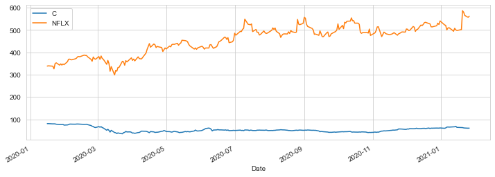

```python
# plot the actual closing price for the two stocks
for tick in tickers:
    stocks[tick]['Close'].plot(figsize=(12,4),label=tick)
plt.legend()
```

### Train-test spliting

There are six trading days for next 10 days period, the testing period are set to be 2021-01-16 to 2021-01-26.

```python
# split train and test
train_data = pd.concat([C['Close'], NFLX['Close']],axis = 1, keys = tickers).loc['2020-01-16':'2021-01-16']
test_data = pd.concat([C['Close'], NFLX['Close']],axis = 1, keys = tickers).loc['2021-01-16':'2021-01-26']
```

```python
train_data
```

| Date | C | NFLX |
| --- | --- | --- |
| 2020-01-16 | 81.000000 | 338.619995 |
| 2020-01-17 | 81.120003 | 339.670013 |
| 2020-01-21 | 79.900002 | 338.109985 |
| 2020-01-22 | 80.099998 | 326.000000 |
| 2020-01-23 | 79.800003 | 349.600006 |
| ... | ... | ... |
| 2021-01-11 | 66.440002 | 499.100006 |
| 2021-01-12 | 66.669998 | 494.250000 |
| 2021-01-13 | 66.860001 | 507.790009 |
| 2021-01-14 | 69.010002 | 500.859985 |
| 2021-01-15 | 64.230003 | 497.980011 |

253 rows × 2 columns

```python
test_data
```

| Date | C | NFLX |
| --- | --- | --- |
| 2021-01-19 | 63.689999 | 501.769989 |
| 2021-01-20 | 63.250000 | 586.340027 |
| 2021-01-21 | 61.869999 | 579.840027 |
| 2021-01-22 | 61.330002 | 565.169983 |
| 2021-01-25 | 60.560001 | 556.780029 |
| 2021-01-26 | 60.910000 | 561.929993 |

### 1. ARIMA model

One of the most basic method dealing with time series data. A significant part of the noise will be averaged out when calculating the moving average, allowing us to observe a long-term behavior of the asset.

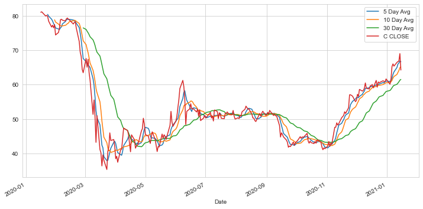

```python
plt.figure(figsize=(12,6))
C['Close'].loc['2020-01-16':'2021-01-16'].rolling(window=5).mean().plot(label='5 Day Avg')
C['Close'].loc['2020-01-16':'2021-01-16'].rolling(window=10).mean().plot(label='10 Day Avg')
C['Close'].loc['2020-01-16':'2021-01-16'].rolling(window=30).mean().plot(label='30 Day Avg')
C['Close'].loc['2020-01-16':'2021-01-16'].plot(label='C CLOSE')
plt.legend()
```

```python
# import the libraries
from statsmodels.tsa.arima_model import ARMA
from statsmodels.tsa.stattools import adfuller
```

```python
# test the stationarity
for tick in tickers:
    print(adfuller(train_data[tick],autolag='AIC'))

# Here the null hypothesis is that the time series data have unit roots, indicating the data instationarity.
# The second value in the output is the p-value of the null hypothesis.
# We failed to reject the null hypothesis. The data lack stationarity and would not be vaild to conduct ARMA model.
```

```
(-2.607858146695566, 0.09138400043532557, 9, 243, {'1%': -3.4575505077947746, '5%': -2.8735087323013526, '10%': -2.573148434859185}, 1025.1013185593129)
(-1.9207472351789128, 0.3223647782002129, 4, 248, {'1%': -3.4569962781990573, '5%': -2.8732659015936024, '10%': -2.573018897632674}, 1870.8075814861813)
```

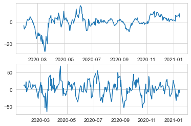

```python
# the following plot of diff sequence prove the previous conclusion. That the variance of prices are not stable.
fig, (ax1,ax2) = plt.subplots(2)
ax1.plot(train_data['C'].diff(9))
ax2.plot(train_data['NFLX'].diff(4))
```

```python
# However, on the 10% confidence level, we can reject the null hypothesis for Citigroup.

from statsmodels.graphics.tsaplots import plot_pacf
from statsmodels.graphics.tsaplots import plot_acf
from statsmodels.tsa.arima_process import ArmaProcess
from statsmodels.stats.diagnostic import acorr_ljungbox
from statsmodels.tsa.statespace.sarimax import SARIMAX
from statsmodels.tsa.stattools import adfuller
from statsmodels.tsa.stattools import pacf
from statsmodels.tsa.stattools import acf
from tqdm import tqdm_notebook
from itertools import product

import warnings
warnings.filterwarnings('ignore')
```

```python
# In order to find the best parameter, define the following function returning dataframe with parameters and corresponding AIC
# order_list - list with (p, d, q) tuples
# exog - the exogenous variable
def optimize_ARIMA(order_list, exog):

    results = []

    for order in tqdm_notebook(order_list):
        try:
            model = SARIMAX(exog, order=order).fit(disp=-1)
        except:
            continue

        aic = model.aic
        results.append([order, model.aic])

    result_df = pd.DataFrame(results)
    result_df.columns = ['(p, d, q)', 'AIC']

    #Sort in ascending order, lower AIC is better
    result_df = result_df.sort_values(by='AIC', ascending=True).reset_index(drop=True)

    return result_df
```

```python
ps = range(0, 8, 1) # autoregressive
d = 1 # differencing
qs = range(0, 8, 1) # moving average

# Create a list with all possible combination of parameters
parameters = product(ps, qs)
parameters_list = list(parameters)

start = time.time()
# Record results of all models
order_list = []
for each in parameters_list:
    each = list(each)
    each.insert(1, 1)
    each = tuple(each)
    order_list.append(each)

result_df = optimize_ARIMA(order_list, exog=train_data['C'])

print('training model takes %s seconds' %round((time.time()-start),3))
```

```
training model takes 17.477 seconds
```

```python
result_df
```

|  | (p, d, q) | AIC |
| --- | --- | --- |
| 0 | (3, 1, 1) | 1090.890204 |
| 1 | (3, 1, 2) | 1091.213389 |
| 2 | (7, 1, 5) | 1091.667311 |
| 3 | (7, 1, 1) | 1092.728183 |
| 4 | (4, 1, 1) | 1092.771883 |
| ... | ... | ... |
| 59 | (0, 1, 5) | 1100.738684 |
| 60 | (2, 1, 3) | 1100.814705 |
| 61 | (6, 1, 0) | 1101.417774 |
| 62 | (7, 1, 7) | 1101.633163 |
| 63 | (0, 1, 6) | 1102.317082 |

64 rows × 2 columns

```python
# The best model is defined to be (3,1,1)
best_model = SARIMAX(train_data['C'], order=(3,1,1)).fit()
print(best_model.summary())
```

```
                               SARIMAX Results
==============================================================================
Dep. Variable:                      C   No. Observations:                  253
Model:               SARIMAX(3, 1, 1)   Log Likelihood                -540.445
Date:                Thu, 28 Jan 2021   AIC                           1090.890
Time:                        00:53:04   BIC                           1108.537
Sample:                             0   HQIC                          1097.991
                                - 253
Covariance Type:                  opg
==============================================================================
                 coef    std err          z      P>|z|      [0.025      0.975]
------------------------------------------------------------------------------
ar.L1         -1.0636      0.046    -23.142      0.000      -1.154      -0.973
ar.L2         -0.0064      0.060     -0.107      0.915      -0.124       0.111
ar.L3          0.1540      0.043      3.554      0.000       0.069       0.239
ma.L1          0.9719      0.029     33.613      0.000       0.915       1.029
sigma2         4.2578      0.258     16.503      0.000       3.752       4.763
===================================================================================
Ljung-Box (L1) (Q):                   0.00   Jarque-Bera (JB):               123.93
Prob(Q):                              0.98   Prob(JB):                         0.00
Heteroskedasticity (H):               0.25   Skew:                            -0.60
Prob(H) (two-sided):                  0.00   Kurtosis:                         6.22
===================================================================================

Warnings:
[1] Covariance matrix calculated using the outer product of gradients (complex-step).
```

Notice that the paramerter for the autoregression at lag 2 is not statistically significant according to the p-value.

The equation would be: $$ {y}'_{t} = -1.0636{y}'_{t-1}-0.0064{y}'_{t-2}+0.154{y}'_{t-3}+0.9719\epsilon _{t-1} $$ With the variance of noise equals to 4.26.

```python
# Prediction
predictions = []
fo = list(train_data['C'].values)
for t in range(len(test_data)):
    model_fit = SARIMAX(fo, order=(3,1,1)).fit()
    # model_fit = model.fit()
    output = model_fit.forecast()
    predictions.append(output[0])
    ob = test_data['C'][t]
    fo.append(ob)

test_data['C ARIMA'] = predictions
test_data
```

[output not shown]

```python
foo = sum((test_data['C']-test_data['C ARIMA'])**2) / len(test_data)
print('The mean squared error of Citigroup is: %.2f' %foo)
```

```
The mean squared error of Citigroup is: 0.64
```

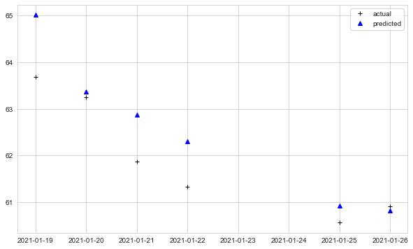

```python
fig = plt.figure(figsize=(10,6))
plt.subplot(111)
plt.plot(test_data['C'],'k+',label = 'actual')
plt.plot(test_data['C ARIMA'],'b^', label = 'predicted')
plt.legend()
```

```python
# The predictions are close to the actual value. The ARIMA model performs well with a MSE of 0.64.
# However, the model has quite strict restrictions that series data has to have stationarity.
```